# Megan Lott Coding Exercise

We’re going to learn to code by playing around with some of the data in the dslabs package.

```r
library(dslabs)
#use the help function tosee what the dataset gapminder contains
help(gapminder)
#?gapminder would also work
#inspect the data
str(gapminder)
```

```
'data.frame':   10545 obs. of  9 variables:
 $ country         : Factor w/ 185 levels "Albania","Algeria",..: 1 2 3 4 5 6 7 8 9 10 ...
 $ year            : int  1960 1960 1960 1960 1960 1960 1960 1960 1960 1960 ...
 $ infant_mortality: num  115.4 148.2 208 NA 59.9 ...
 $ life_expectancy : num  62.9 47.5 36 63 65.4 ...
 $ fertility       : num  6.19 7.65 7.32 4.43 3.11 4.55 4.82 3.45 2.7 5.57 ...
 $ population      : num  1636054 11124892 5270844 54681 20619075 ...
 $ gdp             : num  NA 1.38e+10 NA NA 1.08e+11 ...
 $ continent       : Factor w/ 5 levels "Africa","Americas",..: 4 1 1 2 2 3 2 5 4 3 ...
 $ region          : Factor w/ 22 levels "Australia and New Zealand",..: 19 11 10 2 15 21 2 1 22 21 ...
```

```r
summary(gapminder)
```

```
                country
 Albania            :   57
 Algeria            :   57
 Angola             :   57
 Antigua and Barbuda:   57
 Argentina          :   57
 Armenia            :   57
 (Other)            :10203
      year      infant_mortality
 Min.   :1960   Min.   :  1.50
 1st Qu.:1974   1st Qu.: 16.00
 Median :1988   Median : 41.50
 Mean   :1988   Mean   : 55.31
 3rd Qu.:2002   3rd Qu.: 85.10
 Max.   :2016   Max.   :276.90
                NA's   :1453
 life_expectancy   fertility
 Min.   :13.20   Min.   :0.840
 1st Qu.:57.50   1st Qu.:2.200
 Median :67.54   Median :3.750
 Mean   :64.81   Mean   :4.084
 3rd Qu.:73.00   3rd Qu.:6.000
 Max.   :83.90   Max.   :9.220
                 NA's   :187
   population
 Min.   :3.124e+04
 1st Qu.:1.333e+06
 Median :5.009e+06
 Mean   :2.701e+07
 3rd Qu.:1.523e+07
 Max.   :1.376e+09
 NA's   :185
      gdp               continent
 Min.   :4.040e+07   Africa  :2907
 1st Qu.:1.846e+09   Americas:2052
 Median :7.794e+09   Asia    :2679
 Mean   :1.480e+11   Europe  :2223
 3rd Qu.:5.540e+10   Oceania : 684
 Max.   :1.174e+13
 NA's   :2972
             region
 Western Asia   :1026
 Eastern Africa : 912
 Western Africa : 912
 Caribbean      : 741
 South America  : 684
 Southern Europe: 684
 (Other)        :5586
```

```r
class(gapminder)
```

```
[1] "data.frame"
```

```r
names(gapminder)
```

```
[1] "country"
[2] "year"
[3] "infant_mortality"
[4] "life_expectancy"
[5] "fertility"
[6] "population"
[7] "gdp"
[8] "continent"
[9] "region"
```

By inspecting the data, we can see that gapminder is a data frame that consists of demographic information of the world’s counties. The information includes: infant mortality, life expectancy, fertility, populayion, gdp, continent, region.

We want to look more closely at countries from Africa. We are going to extract that data using the subset() function in base R.

```r
#assign only the African countries to new objects/variables
africadata = subset(gapminder, continent == "Africa")
summary(africadata)
```

```
         country          year
 Algeria     :  57   Min.   :1960
 Angola      :  57   1st Qu.:1974
 Benin       :  57   Median :1988
 Botswana    :  57   Mean   :1988
 Burkina Faso:  57   3rd Qu.:2002
 Burundi     :  57   Max.   :2016
 (Other)     :2565
 infant_mortality life_expectancy
 Min.   : 11.40   Min.   :13.20
 1st Qu.: 62.20   1st Qu.:48.23
 Median : 93.40   Median :53.98
 Mean   : 95.12   Mean   :54.38
 3rd Qu.:124.70   3rd Qu.:60.10
 Max.   :237.40   Max.   :77.60
 NA's   :226
   fertility       population
 Min.   :1.500   Min.   :    41538
 1st Qu.:5.160   1st Qu.:  1605232
 Median :6.160   Median :  5570982
 Mean   :5.851   Mean   : 12235961
 3rd Qu.:6.860   3rd Qu.: 13888152
 Max.   :8.450   Max.   :182201962
 NA's   :51      NA's   :51
      gdp               continent
 Min.   :4.659e+07   Africa  :2907
 1st Qu.:8.373e+08   Americas:   0
 Median :2.448e+09   Asia    :   0
 Mean   :9.346e+09   Europe  :   0
 3rd Qu.:6.552e+09   Oceania :   0
 Max.   :1.935e+11
 NA's   :637
                       region
 Eastern Africa           :912
 Western Africa           :912
 Middle Africa            :456
 Northern Africa          :342
 Southern Africa          :285
 Australia and New Zealand:  0
 (Other)                  :  0
```

Now, we have only 2907 observations. We are interested in examining the infant mortality, life expectancy, and population of the countries in Africa.

```r
#make two new variables: one that contains only infant_mortality and life_expectancy and one that contains only population and life_expectancy. The c() function might be useful to efficiently pull out the variables you want.
africa_data_set1 = subset(africadata, select=c(infant_mortality, life_expectancy))
africa_data_set2 = subset(africadata, select=c(population, life_expectancy))
#You should have two new objects/variables with 2907 rows and two columns.
#NOTE: We no longer have the country information.
#what are the units on infant mortality?
#Use the str, and summary commands to take a look at both variables.
str(africa_data_set1)
```

```
'data.frame':   2907 obs. of  2 variables:
 $ infant_mortality: num  148 208 187 116 161 ...
 $ life_expectancy : num  47.5 36 38.3 50.3 35.2 ...
```

```r
summary(africa_data_set1)
```

```
 infant_mortality life_expectancy
 Min.   : 11.40   Min.   :13.20
 1st Qu.: 62.20   1st Qu.:48.23
 Median : 93.40   Median :53.98
 Mean   : 95.12   Mean   :54.38
 3rd Qu.:124.70   3rd Qu.:60.10
 Max.   :237.40   Max.   :77.60
 NA's   :226
```

We are going to examine the data on infant mortality, life expectancy, and population by plotting this data.

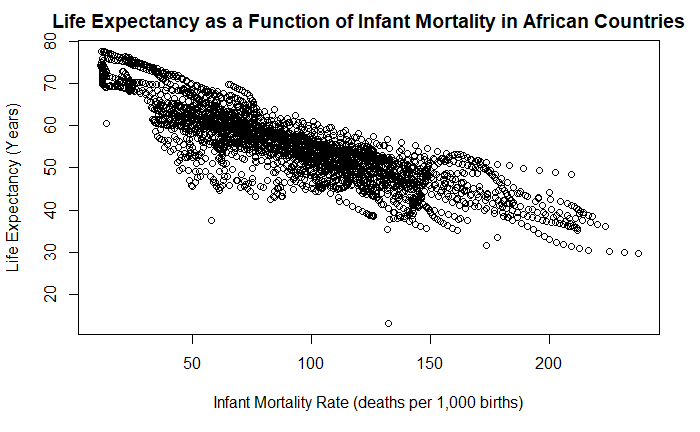

```r
#plot life expectancy as a function of infant mortality
plot(africa_data_set1$infant_mortality, africa_data_set1$life_expectancy, xlab = "Infant Mortality Rate (deaths per 1,000 births)", ylab = "Life Expectancy (Years)", main = "Life Expectancy as a Function of Infant Mortality in African Countries")
```

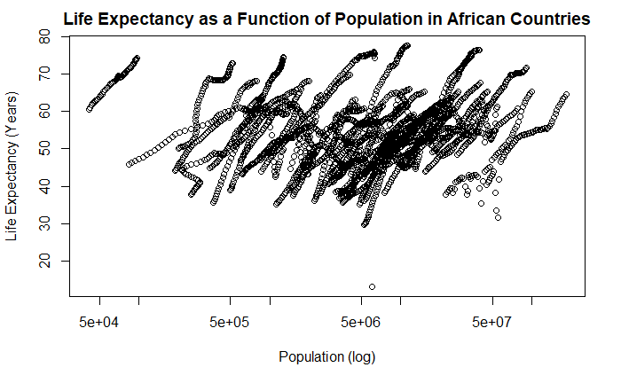

```r
#plot life expectancy as a function of population size
plot(africa_data_set2$population, africa_data_set2$life_expectancy, log = "x", xlab = "Population (log)", ylab = "Life Expectancy (Years)", main = "Life Expectancy as a Function of Population in African Countries")
```

We see a negative correlation between infant mortality and life expectancy. We see a positive correlation between population size and life expectancy, but this data has streaks. **Why is this?**

We have different years for individual countries. Overtime, these countries increase in population size and in life expectancy. To see the relationship between the two variables in focus, we will tease out the data from a single year of interest. We will look at the year for which we have the most amount of data.

```r
#Write some base R code that figures out which years have missing data for infant mortality. The is.na() function might be helpful. You can use the print() function to print the missing years to the console.
#check_na = is.na(africadata$infant_mortality[8])
#print(africadata$year[8])
years_missing_data = data.frame()
x = 2907
for(x in 1:2907){
if(is.na(africadata$infant_mortality[x] == "TRUE")){years_missing_data = rbind(years_missing_data, africadata$year[x])}}
#You should find that there is missing up to 1981 and then again for 2016. So we’ll avoid those years and go with 2000 instead.
#create a new object by extracting only the data for the year 2000 from the africadata object. You should end up with 51 observations and 9 variables. Check it with str and summary
year_2000 = subset(africadata, year == 2000)
str(year_2000)
```

```
'data.frame':   51 obs. of  9 variables:
 $ country         : Factor w/ 185 levels "Albania","Algeria",..: 2 3 18 22 26 27 29 31 32 33 ...
 $ year            : int  2000 2000 2000 2000 2000 2000 2000 2000 2000 2000 ...
 $ infant_mortality: num  33.9 128.3 89.3 52.4 96.2 ...
 $ life_expectancy : num  73.3 52.3 57.2 47.6 52.6 46.7 54.3 68.4 45.3 51.5 ...
 $ fertility       : num  2.51 6.84 5.98 3.41 6.59 7.06 5.62 3.7 5.45 7.35 ...
 $ population      : num  31183658 15058638 6949366 1736579 11607944 ...
 $ gdp             : num  5.48e+10 9.13e+09 2.25e+09 5.63e+09 2.61e+09 ...
 $ continent       : Factor w/ 5 levels "Africa","Americas",..: 1 1 1 1 1 1 1 1 1 1 ...
 $ region          : Factor w/ 22 levels "Australia and New Zealand",..: 11 10 20 17 20 5 10 20 10 10 ...
```

```r
summary(year_2000)
```

```
         country        year
 Algeria     : 1   Min.   :2000
 Angola      : 1   1st Qu.:2000
 Benin       : 1   Median :2000
 Botswana    : 1   Mean   :2000
 Burkina Faso: 1   3rd Qu.:2000
 Burundi     : 1   Max.   :2000
 (Other)     :45
 infant_mortality life_expectancy
 Min.   : 12.30   Min.   :37.60
 1st Qu.: 60.80   1st Qu.:51.75
 Median : 80.30   Median :54.30
 Mean   : 78.93   Mean   :56.36
 3rd Qu.:103.30   3rd Qu.:60.00
 Max.   :143.30   Max.   :75.00

   fertility       population
 Min.   :1.990   Min.   :    81154
 1st Qu.:4.150   1st Qu.:  2304687
 Median :5.550   Median :  8799165
 Mean   :5.156   Mean   : 15659800
 3rd Qu.:5.960   3rd Qu.: 17391242
 Max.   :7.730   Max.   :122876723

      gdp               continent
 Min.   :2.019e+08   Africa  :51
 1st Qu.:1.274e+09   Americas: 0
 Median :3.238e+09   Asia    : 0
 Mean   :1.155e+10   Europe  : 0
 3rd Qu.:8.654e+09   Oceania : 0
 Max.   :1.329e+11

                       region
 Eastern Africa           :16
 Western Africa           :16
 Middle Africa            : 8
 Northern Africa          : 6
 Southern Africa          : 5
 Australia and New Zealand: 0
 (Other)                  : 0
```

Now, we can examine the relationship between infant mortality, life expectancy, and population in the Year 2000.

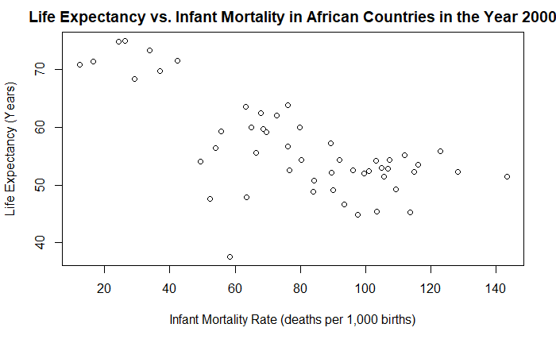

```r
#use base R plotting again and do the same two plots again, this time only for the year 2000
plot(year_2000$infant_mortality, year_2000$life_expectancy, xlab = "Infant Mortality Rate (deaths per 1,000 births)", ylab = "Life Expectancy (Years)", main = "Life Expectancy vs. Infant Mortality in African Countries in the Year 2000")
```

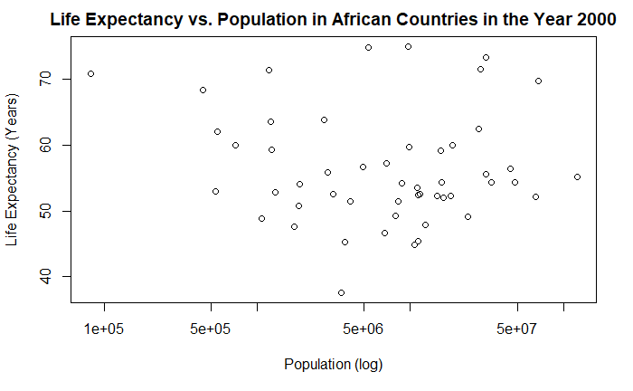

```r
plot(year_2000$population, year_2000$life_expectancy, log = "x", xlab = "Population (log)", ylab = "Life Expectancy (Years)", main = "Life Expectancy vs. Population in African Countries in the Year 2000")
```

We see that there is a negative correlation between infant mortality and life expectancy, but no noticeable correlation between population size and life expectancy.

```r
# Use the lm function and fit life expectancy as the outcome, and infant mortality as the predictor. Then use the population size as the predictor.
fit1 = lm(year_2000$life_expectancy ~ year_2000$infant_mortality)
summary(fit1)
```

```
Call:
lm(formula = year_2000$life_expectancy ~ year_2000$infant_mortality)

Residuals:
     Min       1Q   Median       3Q
-22.6651  -3.7087   0.9914   4.0408
     Max
  8.6817

Coefficients:
                           Estimate
(Intercept)                71.29331
year_2000$infant_mortality -0.18916
                           Std. Error
(Intercept)                   2.42611
year_2000$infant_mortality    0.02869
                           t value
(Intercept)                 29.386
year_2000$infant_mortality  -6.594
                           Pr(>|t|)
(Intercept)                 < 2e-16
year_2000$infant_mortality 2.83e-08

(Intercept)                ***
year_2000$infant_mortality ***
---
Signif. codes:
  0 ‘***’ 0.001 ‘**’ 0.01 ‘*’ 0.05
  ‘.’ 0.1 ‘ ’ 1

Residual standard error: 6.221 on 49 degrees of freedom
Multiple R-squared:  0.4701,    Adjusted R-squared:  0.4593
F-statistic: 43.48 on 1 and 49 DF,  p-value: 2.826e-08
```

```r
fit2 = lm(year_2000$life_expectancy ~ year_2000$population)
summary(fit2)
```

```
Call:
lm(formula = year_2000$life_expectancy ~ year_2000$population)

Residuals:
    Min      1Q  Median      3Q
-18.429  -4.602  -2.568   3.800
    Max
 18.802

Coefficients:
                      Estimate
(Intercept)          5.593e+01
year_2000$population 2.756e-08
                     Std. Error
(Intercept)           1.468e+00
year_2000$population  5.459e-08
                     t value Pr(>|t|)
(Intercept)           38.097   <2e-16
year_2000$population   0.505    0.616

(Intercept)          ***
year_2000$population
---
Signif. codes:
  0 ‘***’ 0.001 ‘**’ 0.01 ‘*’ 0.05
  ‘.’ 0.1 ‘ ’ 1

Residual standard error: 8.524 on 49 degrees of freedom
Multiple R-squared:  0.005176,  Adjusted R-squared:  -0.01513
F-statistic: 0.2549 on 1 and 49 DF,  p-value: 0.6159
```

The p-value for fit1 is 2.826e-08. There is a significant correlation between life expectancy and infant mortality. The p-value for fit2 is 0.6159. There is no significant correlation between life expectancy and population.